# STA 506 Final Examination

Sean Schilk

May 5, 2026

## **Final Exam Guidelines**

- **Coverage**: The major concepts and inference procedures—such as sampling distributions, confidence intervals, and hypothesis testing—are covered and implemented using both classical parametric likelihood-based methods and modern non-parametric approaches, including the bootstrap and kernel density estimation.
- **Part A** requires derivation of selected likelihood-based functions for performing various types of inference, with sufficient detail to enable translation of these derivations into code for numerical analysis.
- Your code for the problems in **Part B** must align with your derivations in **Part A** and be well commented where necessary.
- In **Part B**, all numerical results must be interpreted from a practical perspective.

## **Policies of Using AI Tools**

- **Policy on AI Tool Use**: Students must adhere to the AI tool policy specified in the course syllabus. The direct copying of AI-generated content is strictly prohibited. All submitted work must reflect your own understanding; where external tools are consulted, content must be thoroughly rephrased and synthesized in your own words.
- **Code Inclusion Requirement**: Any code included in your essay must be properly commented to explain the purpose and/or expected output of key code lines. Submitting AI-generated code without meaningful, student-added comments will not be accepted.

## **Working Model for the Final Exam**

**Caution**: *Please follow the suggested expressions and guided steps to complete the exam. Other approaches such as transformation for trivialize the problems that will not meet the exam objectives.*

The **Kumaraswamy distribution** is a two-parameter continuous probability distribution defined on the interval (0, 1). It is often used as an alternative to the Beta distribution due to its simple closed-form expressions for the cumulative distribution function (CDF) and quantile function. It is commonly used in

- **Hydrology**: Modeling rainfall, streamflow, or other bounded natural phenomena
- **Economics**: Income shares, proportions, or bounded indices
- **Monte Carlo simulation**: Efficient random variate generation (via inverse transform)
- **Machine learning**: Output layer for bounded targets, prior distributions in Bayesian models
- **Reliability engineering**: Modeling failure rates of systems with bounded lifetimes

Let $X$ be the Kumaraswamy random variable with Cumulative Distribution Function (CDF)

$$F(x; a, b) = 1 - (1 - x^a)^b$$

where $a > 0$ and $b > 0$ unknown parameters and $0 < x < 1$.

The following are two special case of the Kumaraswamy distribution:

1. **Uniform Distribution**: When $a = 1$ and $b = 1$, the Kumaraswamy distribution becomes a uniform distribution over $[0, 1]$ with CDF $F(x) = x$.
2. **Power Distribution**: when $b = 1$ and $a > 0$, the Kumaraswamy distribution becomes a power distribution over $[0, 1]$ with CDF $F(x) = x^a$.

This final exam focuses on inferences of Kumaraswamy distribution and related data analysis.

## Part A: Methodological Derivations

### **Problem A1**:

Show that the density function of the Kumaraswamy distribution is

$$f(x; a, b) = ab \, x^{a-1} (1 - x^a)^{b-1}.$$

### **Problem A2**:

Let $\{x_1, x_2, \cdots, x_n \}$ be an i.i.d. random sample taken from a population that follows the aove 2-parameter Kumaraswamy distribution. Write out the loglikelihood function of $a$ and $b$, denoted by $\ell(a,b)$, based on the above random sample and **derive** the gradient vector $[\ell_a^\prime(a,b), \ell_b^\prime(a,b)]$, the first order partial derivative of the log-likelihood with respect to parameters $a$ and $b$.

### **Problem A3**:

Based on the gradients functions obtained in the above problem A2, **derive** the observed Fisher Information matrix (i.e, the negative Hessian Matrix).

### **Problem A4**:

Consider power distribution $F(x) = x^a, (a >0 \quad \text{ and }\quad x \in (0,1))$, a special case of the Kumaraswamy distribution with $b = 1$, and a random sample from this distribution $\{ x_1, x_2, \cdots, x_n\}$. **Derive** the MLE and MME of $a$ respectively. [*Hint: To find the MME, you need to compute the moment of the power distribution; that is, $E[X^k] = \int_0^1 x^k F'(x) dx$. Note that both the MLE and the MME have closed-form expressions.*]

### **Problem A5**:

Using the same setting as in **Problem A4**, find the asymptotic (Wald) confidence interval for $a$. [*Hint: Compute the Fisher information for $a$, then take its reciprocal to obtain the variance*.]

### **Problem A6**:

Using the same setting as in **Problem A4**, perform a likelihood ratio test for the hypothesis $H_0 :a=1$ (i.e., the power distribution reduces to a uniform distribution). [*Hint: Evaluate the log-likelihood function at the maximum likelihood estimate $\hat{a}$ and at $a=1$, then use these values to construct the LRT test statistic.*]

```r
knitr::include_graphics("https://sschilk.github.io/STA-506/FinalProj/STA506.1.jpeg")
```

[figure not shown]

```r
knitr::include_graphics("https://sschilk.github.io/STA-506/FinalProj/STA506.2.jpeg")
```

[figure not shown]

```r
knitr::include_graphics("https://sschilk.github.io/STA-506/FinalProj/STA506.3.jpeg")
```

[figure not shown]

```r
knitr::include_graphics("https://sschilk.github.io/STA-506/FinalProj/STA506.4.jpeg")
```

[figure not shown]

```r
# In section A4) i want to clarify the MLE for a_hat is -1 / lnx_bar, where lnx_bar is mean(log(x)), not simply log(mean(x)).
```

## Part B: Numerical Analysis

**All code must be well commented and adhere to best coding practices**

**Working Dataset**: A small reservoir supplies water to a town. During the dry season (50 days), engineers record the fraction of usable storage filled each morning. Values near 0 mean the reservoir is nearly empty; values near 1 mean it’s full. The distribution tends to be right‑skewed (mostly low levels due to drought) but with occasional replenishment.

The following 50 data points (ordered for clarity) represent the daily proportion of usable storage:

```r
usable_storage_frac <- c(0.12, 0.14, 0.15, 0.16, 0.17, 0.18, 0.19, 0.20, 0.21, 0.22,
0.23, 0.24, 0.25, 0.26, 0.27, 0.28, 0.29, 0.30, 0.31, 0.32,
0.33, 0.34, 0.35, 0.36, 0.37, 0.38, 0.39, 0.40, 0.41, 0.42,
0.43, 0.44, 0.45, 0.46, 0.47, 0.48, 0.49, 0.50, 0.51, 0.52,
0.53, 0.54, 0.55, 0.56, 0.57, 0.58, 0.59, 0.60, 0.61, 0.78)
```

### **Problem B1**:

Fit the Kumaraswamy distribution to the above data. Use the derivations in **Problem A2** to find the MLE of $a$ and $b$. Please copy the key formulas before coding.

```r
Kumaraswamy.loglik <- function(params, x) {
  a <- params[1] # passing the parameters
  b <- params[2]

  n <- length(x) # sample size

  loglik <- n*log(a) + n*log(b) + (a-1)*sum(log(x)) + (b-1)*sum(log(1-x^a)) # from A2) above

  return(loglik) # Return negative for minimization
}

# Score (gradient) equation
Kumaraswamy.score <- function(params, x) {
  a <- params[1]
  b <- params[2]
  n <- length(x)

  grad_a <- n/a + sum(log(x)) - (b-1)*sum((x^a * log(x))/(1 - x^a))
  grad_b <- n/b + sum(log(1-x^a))

  return(c(grad_a, grad_b))
}

# Initial starting values we already derived
initial.params <- c(a = -1/mean(log(usable_storage_frac)), b = 1)

# Using optim with Nelder-Mead method
mle_result <- optim(
  par = initial.params,
  fn = Kumaraswamy.loglik,
  gr = Kumaraswamy.score,
  x = usable_storage_frac,
  method = "L-BFGS-B",
  hessian = TRUE,
  control = list(trace = FALSE,
                 fnscale = -1,
                 maxit = 500,
                 abstol = 1e-8)
)
##
mle_result
```

```
$par
       a        b
2.529591 7.883301

$value
[1] 24.56271

$counts
function gradient
      16       16

$convergence
[1] 0

$message
[1] "CONVERGENCE: REL_REDUCTION_OF_F <= FACTR*EPSMCH"

$hessian
           a          b
a -38.997975  4.8616147
b   4.861615 -0.8045515
```

### **Problem B2**:

Fit the **power distribution** to the above data using the derived of $a$ obtained in **Problem A4** to test the following hypothesis using likelihood ratio procedure ar significance level $\alpha = 0.05$:

$$H_0: b = 1 \quad \text{ versus } \quad H_a: b \ne 1.$$

```r
#estimated aMLE
a_MLE <- -1/mean(log(usable_storage_frac))
##loglike function
loglik <- function(b) n*log(b) + (b-1)*sum(log(1-usable_storage_frac^a_MLE))
##score
score  <- function(b) n/b + sum(log(1 - usable_storage_frac^a_MLE))

n <- length(usable_storage_frac) # data set sample size

result0 <- optim(
  par     = 1,
  fn      = loglik,
  gr      = score,
  method  = "BFGS",
  hessian = TRUE,
  control = list(
    fnscale = -1,
    maxit   = 1000,
    reltol  = 1e-8
  )
)

 result0
```

```
$par
[1] 1.833608

$value
[1] 7.582917

$counts
function gradient
      16        6

$convergence
[1] 0

$message
NULL

$hessian
          [,1]
[1,] -14.87159
```

```r
 ##
 LR <- -2 * (loglik(result0$par) - Kumaraswamy.loglik(mle_result$par, x = usable_storage_frac))
 LR
```

```
       a
33.95958
```

```r
pval <-  1- pchisq(LR, df = 1)
pval
```

```
           a
5.626887e-09
```

State the statistical decision clearly. What is the practical implication of the testing result?

The p-value is nearly zero, leading to the rejection of the null hypothesis. Therefore the the power distribution is not an adequate model for the data. We need the 2 parameter Kumaraswamy dist. to fit the data.

### **Problem B3**:

Use the procedure and code from **Problem B1** to estimate the MLEs of $a$ and $b$, and then complete the following analyses:

```r
kumaraswamy_mle <- function(x) {
  opt <- optim(par    = c(-1/mean(log(x)), 1),
               fn     = Kumaraswamy.loglik,
               gr     = Kumaraswamy.score,
               x      = x,
               method = "L-BFGS-B",
               lower  = c(1e-6, 1e-6),
               control = list(fnscale = -1))   # maximize instead of minimize

  return(list(a_hat = opt$par[1], b_hat = opt$par[2]))
}
##
kumaraswamy_mle(usable_storage_frac)
```

```
$a_hat
[1] 2.529591

$b_hat
[1] 7.883301
```

(1). Obtain the bootstrap sampling distributions of $\hat{a}$ and $\hat{b}$ and plot each distribution using **Gaussian kernel density curves**.

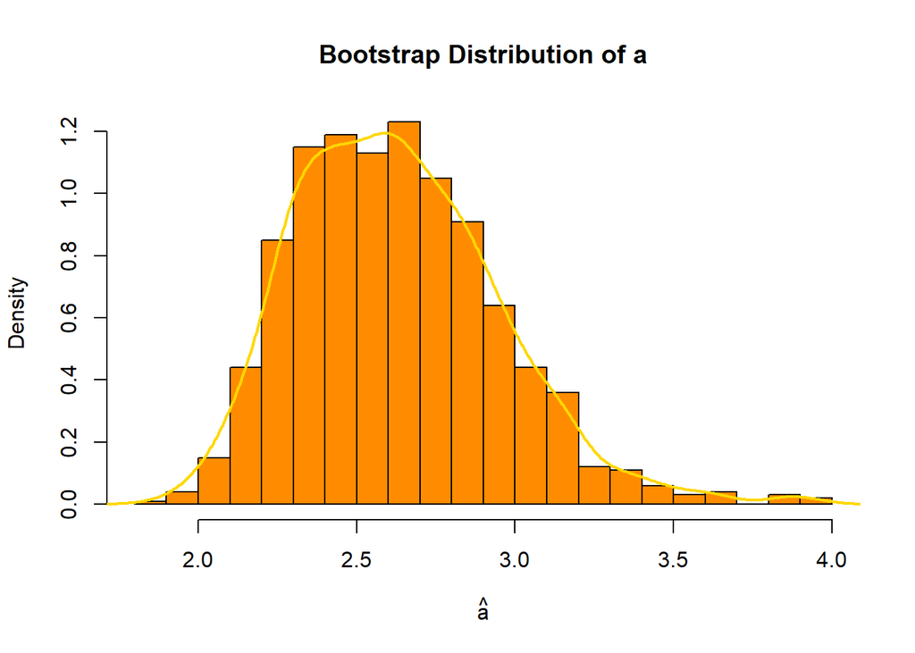

```r
#a
set.seed(1)  # for reproducibility
boot_a <- NULL # set initial null

for (i in 1:1000) {
  x_star <- sample(usable_storage_frac,
                   size = length(usable_storage_frac), #sample size
                   replace = TRUE
                   )

  boot_a[i] <- kumaraswamy_mle(x_star)$a_hat
}

#plot bootstrap histogram
hist(boot_a, probability = TRUE, breaks = 20,
     main = "Bootstrap Distribution of a",
     xlab = expression(hat(a)), col = "darkorange")
lines(density(boot_a), col = "gold", lwd = 2) #kernel density
```

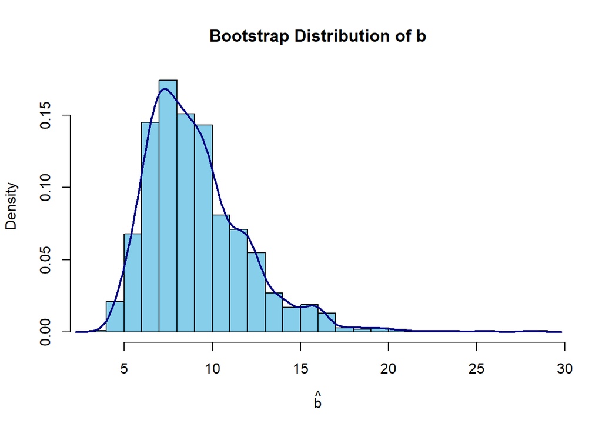

```r
#b
set.seed(1)  # for reproducibility
boot_b <- NULL # set initial null

for (i in 1:1000) {
  x_star <- sample(usable_storage_frac,
                   size = length(usable_storage_frac), #sample size
                   replace = TRUE
                   )

  boot_b[i] <- kumaraswamy_mle(x_star)$b_hat
}

#plot bootstrap histogram
hist(boot_b, probability = TRUE, breaks = 20,
     main = "Bootstrap Distribution of b",
     xlab = expression(hat(b)), col = "skyblue")
lines(density(boot_b), col = "navy", lwd = 2) #kernel density
```

(2). Construct both the $95\%$ **bootstrap confidence interval** and the **Wald confidence interval** for $b$. Do these intervals agree with the results obtained in **Problem B2**? [*Compute the standard error of $\hat{b}$ using the observed Fisher information matrix, i.e., the inverse of the negative Hessian obtained from optim()*]

```r
#bootstrap ci
boot_b_sE <- sd(boot_b)
boot_b_CI <- c(kumaraswamy_mle(usable_storage_frac)$b_hat - 1.96 * boot_b_sE,
               kumaraswamy_mle(usable_storage_frac)$b_hat + 1.96 * boot_b_sE)

boot_b_CI
```

```
[1]  2.204944 13.561657
```

```r
#wald
mle_hessian <- optim(par     = c(kumaraswamy_mle(usable_storage_frac)$a_hat, kumaraswamy_mle(usable_storage_frac)$b_hat),
                     fn      = Kumaraswamy.loglik,
                     gr      = Kumaraswamy.score,
                     x       = usable_storage_frac,
                     method  = "L-BFGS-B",
                     lower   = c(1e-6, 1e-6),
                     hessian = TRUE,
                     control = list(fnscale = -1))
mle_hessian
```

```
$par
[1] 2.529590 7.883301

$value
[1] 24.56271

$counts
function gradient
       3        3

$convergence
[1] 0

$message
[1] "CONVERGENCE: REL_REDUCTION_OF_F <= FACTR*EPSMCH"

$hessian
           [,1]       [,2]
[1,] -38.998002  4.8616174
[2,]   4.861617 -0.8045514
```

```r
mle_result # similar hessians
```

```
$par
       a        b
2.529591 7.883301

$value
[1] 24.56271

$counts
function gradient
      16       16

$convergence
[1] 0

$message
[1] "CONVERGENCE: REL_REDUCTION_OF_F <= FACTR*EPSMCH"

$hessian
           a          b
a -38.997975  4.8616147
b   4.861615 -0.8045515
```

```r
varcov <- solve(-mle_hessian$hessian)
varcov
```

```
          [,1]      [,2]
[1,] 0.1039395 0.6280695
[2,] 0.6280695 5.0381293
```

```r
b.se <- sqrt(varcov[2, 2])  # the square root of the bottom right
b.se
```

```
[1] 2.244578
```

```r
Wald_CI <- c(kumaraswamy_mle(usable_storage_frac)$b_hat - 1.96 * b.se,
               kumaraswamy_mle(usable_storage_frac)$b_hat + 1.96 * b.se)
Wald_CI
```

```
[1]  3.483928 12.282673
```

As b=1 is not in the interval either Bootstrap nor Wald’s Confidence Intervals, this agrees with what we found in B2, where we rejected the null that b=1.

### **Problem B4**:

In the introduction to the working model for this exam, the Kumaraswamy distribution reduces to the uniform distribution on (0,1). In this problem, we perform a **likelihood ratio test** for the following hypothesis to assess whether the data come from the uniform distribution on (0,1):

$$H_0: a = 1\quad \& \quad b = 1\quad \text{ versus } \quad H_a: a \ne
1 \quad \text{or} \quad b \ne 1 \quad \text{or}\quad (a \ne 1 \quad
\& \quad b \ne 1).$$

```r
ll_H0 <- Kumaraswamy.loglik(c(1, 1), usable_storage_frac)

ll_Ha <- Kumaraswamy.loglik(c(kumaraswamy_mle(usable_storage_frac)$a_hat, kumaraswamy_mle(usable_storage_frac)$b_hat), usable_storage_frac)

LR <- -2 * (ll_H0 - ll_Ha)
LR
```

```
[1] 49.12542
```

```r
pval <- 1 - pchisq(LR, df = 2)
pval
```

```
[1] 2.150558e-11
```

Provide a practical interpretation of the above test result. [*Hint: $H_a$ basically says that there is no constraints for $a$ and $b$. Please review the lecture note for module 11 on the likelihood ratio test before coding.*]

As p<.05, we conclude that the data does not come from a uniform distribution on (0,1). If it were true that the data did follow a uniform distribution, that would mean the reservoir is equally likely to be at any given fill level in the morning, both 10% full and 90% full having the same chance on any given day. But we can assume it would have lower levels during a drought, so it wouldn’t make sense to be uniform.